# Project 3 - EDA

- Show All Code
- Hide All Code
- View Source

Author

Max Lippman, Marti Walstad, Jenna Sayle, Alaina Edwards

## Business Value Propositions

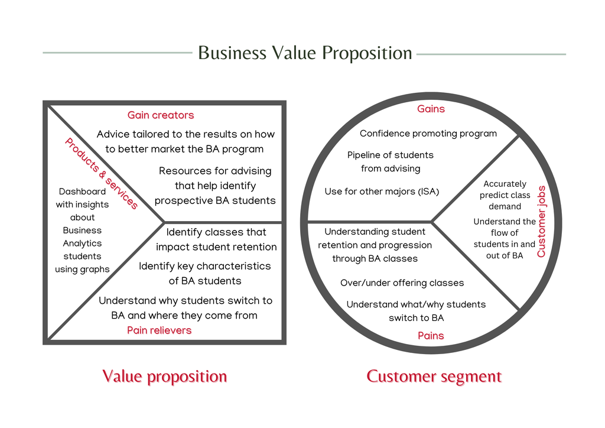

Client:

- Skip Benamati Professor and chair of the Information Systems & Analytics along with his staff including Alan Clift (Data and planning Analyst)

Jobs:

- Accurately predict demand for classes
- Understand the flow of students in and out of Business Analytics major

Pains:

- Before:
  - Abundance of BA majors who end up dropping
- During:
  - Student retention – understanding characteristics of students who stay and do not stay with the BA major
  - Understanding what students are switching to the BA major
  - If BA courses have an impact on whether students stay in business analytics
- After:
  - Over offering classes (results in too many small sized classes)

Solution:

- Dashboard with insights about Business Analytics students using graphs and other visuals

Pain Killers:

- Identify key characteristics of students who leave the major
- Identify classes that may need curriculum change in order to retain my students
- Understand why students switch to the BA major and what majors they come from

Gains:

- Confidence promoting program
- Pipeline of students from advising
- Use for other majors (ISA)

Gain Creators:

- Advice tailored to the results on how to better market the BA program
- Resources for advising that help identify prospective BA students

## Research Question

It is challenging to predict demand for the program and course size for the Business Analytics program. Skip and the BA department would like to know the forecasted number of students so that courses are not offered over abundantly or insufficiently.

- How many students are forecasted to be in the Spring 2024 BA cohort?
- Is there a relationship between any student characteristics and students who stay with the BA major?
- Is there a relationship between any student characteristics and students who leave the BA major?
- Are there any majors at Miami University that have a relationship with students joining or leaving the BA program?
- Do certain courses moderate the relationship between students joining and leaving the BA program?

To answer these questions, are building a time series analysis of the number of students in each program (Business Analytics Major, Business Analytics Minor, and Applied Business Statistics Thematic Sequence) to project the growth in these programs. We also built a random forest model to predict if a student with drop a Business Analytics program.

## Session Information

For the purpose of data reproducibility, we included the session info and loaded all required packages in this one location.

[session information not shown]

## Time Series Analysis

The following charts are the distinct counts of students enrolled in each business analytics programs. Programs include the Business Analytics Major, Minor, and thematic sequenced (named Applied Business Statistics). Each program is plotted individually over term from fall 2018 to fall 2024. We intend on adding to each bar chart the % growth each semester and a line of best fit. Plotting the line of best fit will return a prediction for a future semester.We also intend on continuing to improve the aesthetics and understandably of each graph with better labeling and spacing.

### ISA2 Applied Business Statistics Thematic Sequence over Terms

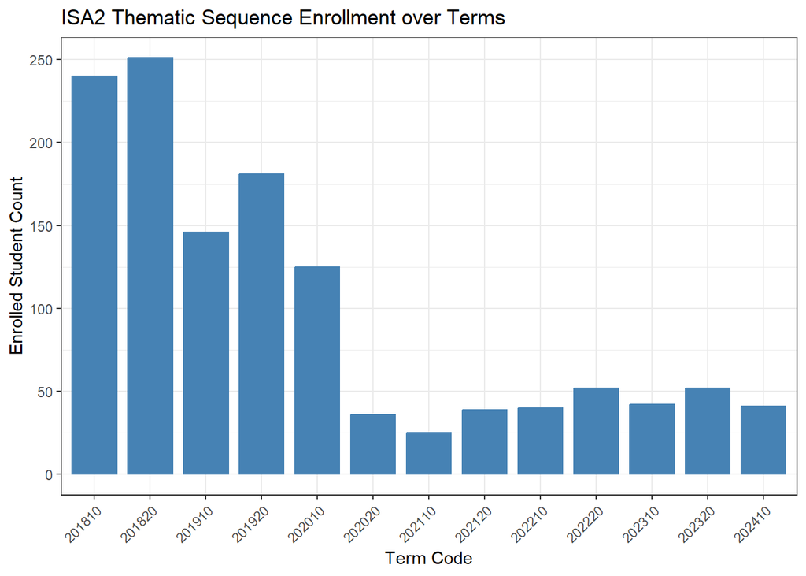

```r
data = read_excel("Thematic Sequence.xlsx")
p = ggplot(data, aes(x = `Term Code`, y = `Enrolled Student Count`)) +
  geom_bar(stat = "identity", color = "steelblue", fill = "steelblue", width = 0.8) +
  xlab("Term Code") +
  ylab("Enrolled Student Count") +
  ggtitle("ISA2 Thematic Sequence Enrollment over Terms") +
  theme_bw() +
  theme(axis.text.x = element_text(angle = 45, hjust = 1))  # Rotate x-axis labels for better visibility

p
```

### Business Analytics Minor over Terms

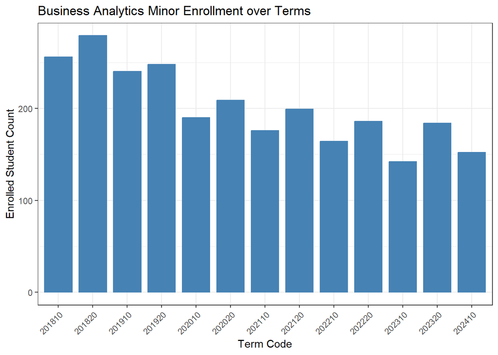

```r
data = read_excel("BA Minors.xlsx")

p = ggplot(data, aes(x = `Term Code`, y = `Enrolled Student Count`)) +
  geom_bar(stat = "identity", color = "steelblue", fill = "steelblue", width = 0.8) +
  xlab("Term Code") +
  ylab("Enrolled Student Count") +
  ggtitle("Business Analytics Minor Enrollment over Terms") +
  theme_bw() +
  theme(axis.text.x = element_text(angle = 45, hjust = 1))

p
```

### Business Analytics Major over Term

```r
merged_data = read.csv('StudentData')


ba_major_counts_by_term <- aggregate(Major.1 ~ Term.Code, data = merged_data, function(x) sum(x == "BA Major"))


ba_major_counts_by_term2 <- aggregate(Major.2 ~ Term.Code, data = merged_data, function(x) sum(x == "BA Major"))

ba_major_counts_by_term3 <- aggregate(Major.3 ~ Term.Code, data = merged_data, function(x) sum(x == "BA Major"))

# Assuming ba_major_counts_by_term, ba_major_counts_by_term2, ba_major_counts_by_term3 are your data frames
merged_counts <- merge(ba_major_counts_by_term, ba_major_counts_by_term2, by = "Term.Code", all = TRUE)
merged_counts <- merge(merged_counts, ba_major_counts_by_term3, by = "Term.Code", all = TRUE)

# Replace missing values with zeros
merged_counts[is.na(merged_counts)] <- 0

# Set column names for clarity
names(merged_counts) <- c("Term.Code", "BA_Major_Count_1", "BA_Major_Count_2", "BA_Major_Count_3")

# Display the result
print(merged_counts)
```

```
   Term.Code BA_Major_Count_1 BA_Major_Count_2 BA_Major_Count_3
1     201810                0                0                0
2     201820                0                0                0
3     201910                0                0                0
4     201920                0                0                0
5     202010                8                0                0
6     202020               17                3                0
7     202110               46                3                0
8     202120               68                4                0
9     202210              174                6                0
10    202220              185                7                0
11    202310              284                9                0
12    202320              279               12                0
13    202410              345               11                0
```

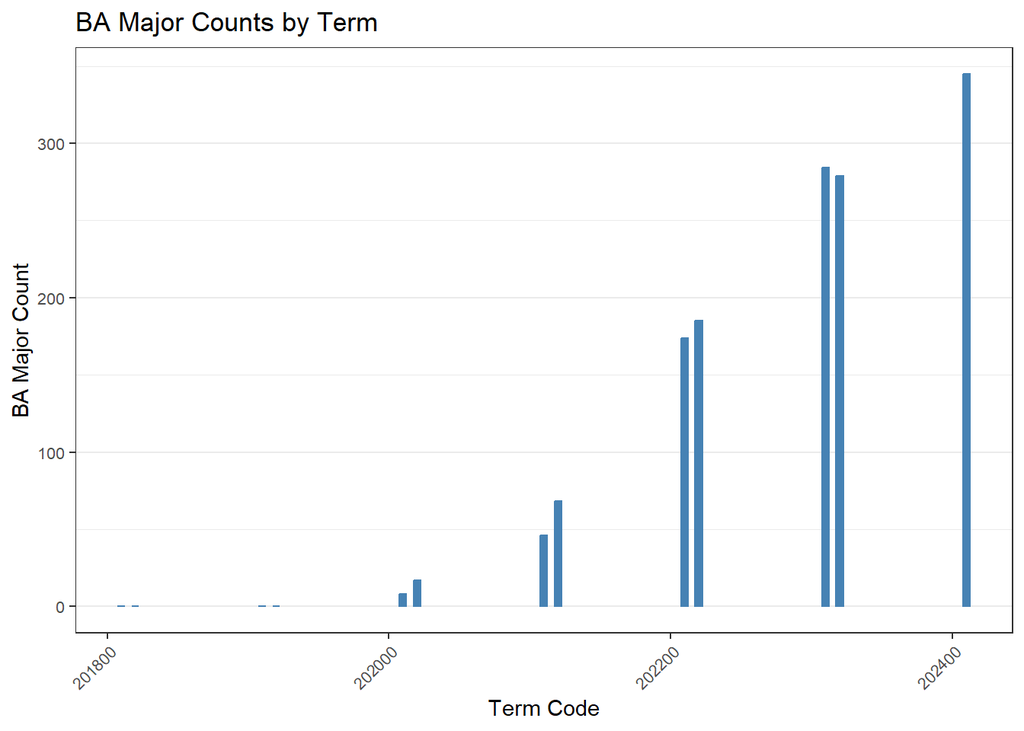

```r
p <- ggplot(merged_counts, aes(x = Term.Code)) +
  geom_bar(aes(y = BA_Major_Count_1), stat = "identity", position = "dodge", fill = "steelblue", color = "steelblue", width = 5) +
  geom_bar(aes(y = BA_Major_Count_2), stat = "identity", position = "dodge", fill = "steelblue", color = "steelblue", width = 5) +
  geom_bar(aes(y = BA_Major_Count_3), stat = "identity", position = "dodge", fill = "steelblue", color = "steelblue", width = 5) +
  xlab("Term Code") +
  ylab("BA Major Count") +
  ggtitle("BA Major Counts by Term") +
  theme_bw()+
  theme(axis.text.x = element_text(angle = 45, hjust = 1),
        axis.text = element_text(size = 8),  # Adjust the size of axis text
        panel.grid.major.x = element_blank(),  # Hide major gridlines
        panel.grid.minor.x = element_blank())
p
```

## Random Forest Model

Our goal is to understand a business analytics student’s progression through their program and therefore we added a flag (column with 1 or 0) to denote if they left their program or not (1= leave, 0 = stay) at anytime. With this information, we can track what students leave which we used in a predictive model as the target variable.

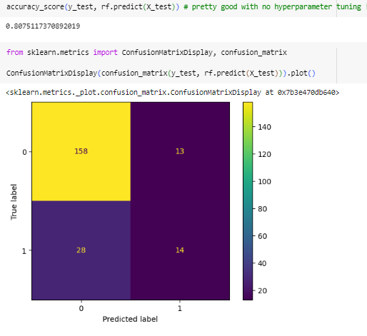

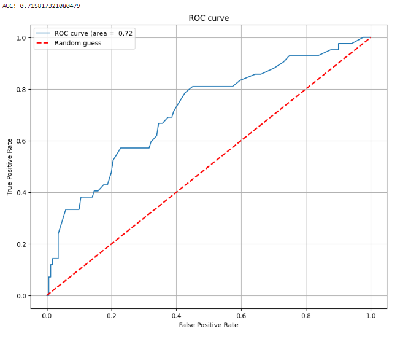

[figure not shown]

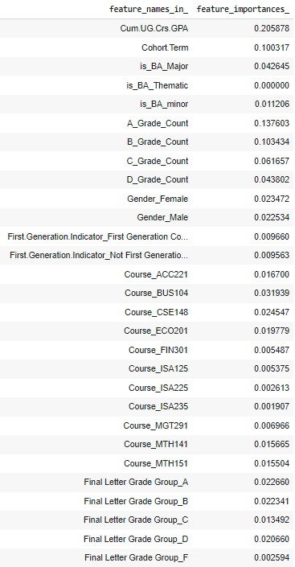